# IODS course project

## Linear analysis

Lets define exam points as dependent variable. Variables with highest correlation coefficients related to exam points are attitude, stratetig learning and surface learning. They are the independent variables in our model

$$Y_{i} = \beta_{0} + \beta_{1}X_{1i} + \beta_{2}X_{2i} + \beta_{3}X_{3i} + \varepsilon_{i}$$
where $Y_{i}$ is exam points, $X_{1i}$ is attitude, $X_{2i}$ is stratetig learning and $X_{3i}$ is surface learning.

Here are the plotted values of each variable:

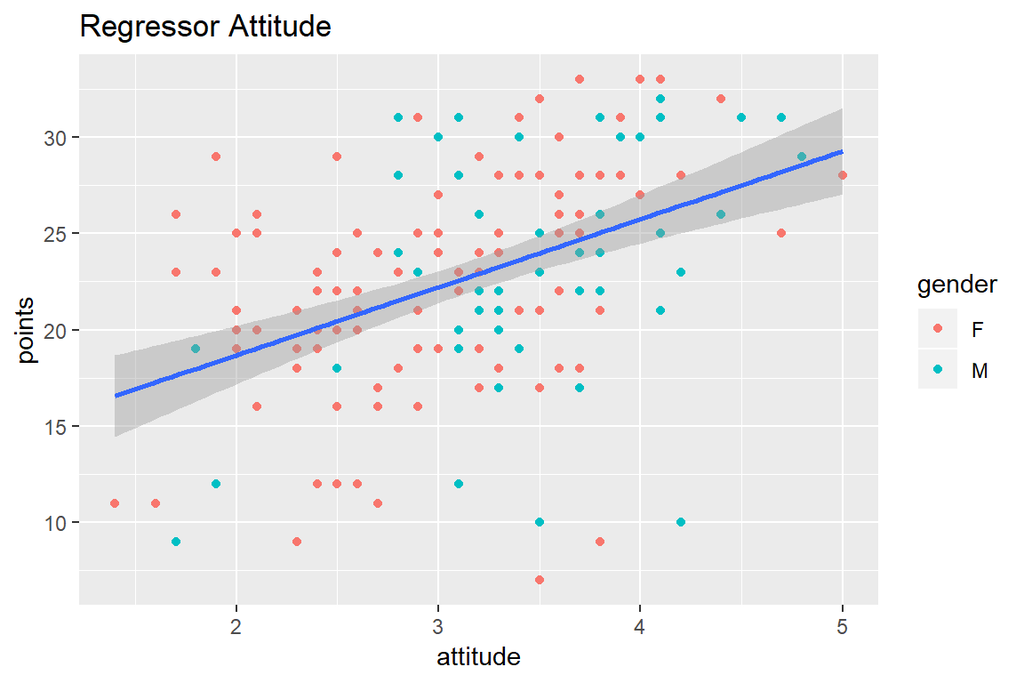

```r
qplot(attitude, points, data = lrn14, aes(col = gender)) + geom_smooth(method = "lm") + ggtitle("Regressor Attitude")
```

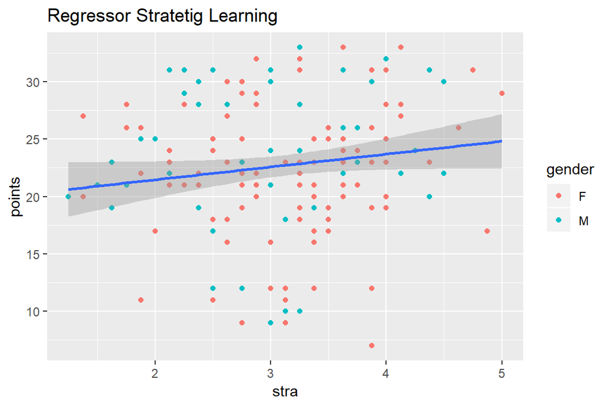

```r
qplot(stra, points, data = lrn14, aes(col = gender)) + geom_smooth(method = "lm") + ggtitle("Regressor Stratetig Learning")
```

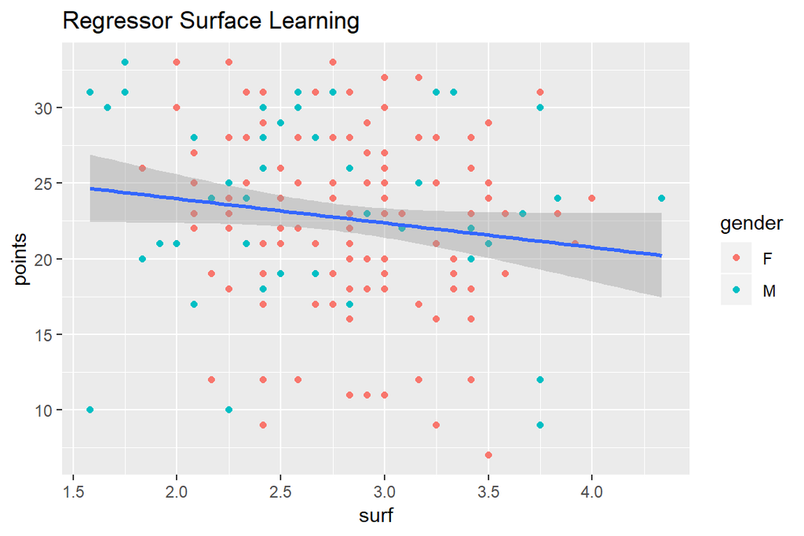

```r
qplot(surf, points, data = lrn14, aes(col = gender)) + geom_smooth(method = "lm") + ggtitle("Regressor Surface Learning")
```

Lets analyse our linear model $Y_{i} = \beta_{0} + \beta_{1}X_{1i} + \beta_{2}X_{2i} + \beta_{3}X_{3i} + \varepsilon_{i}$.

At first we must check the model assumptions:

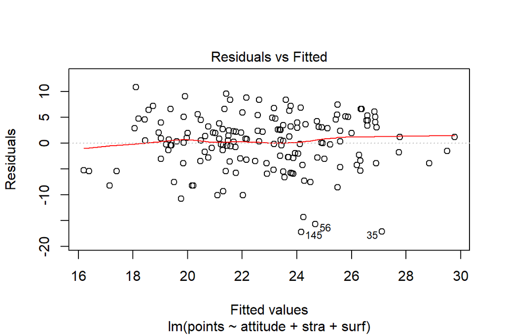

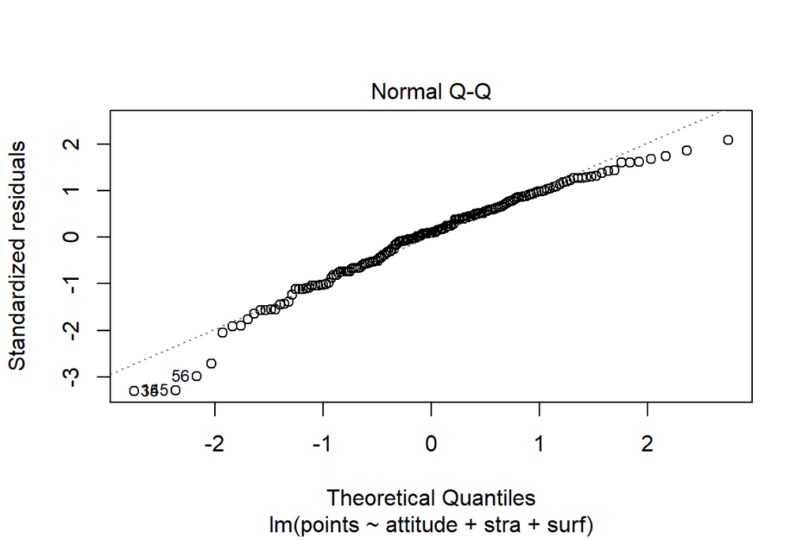

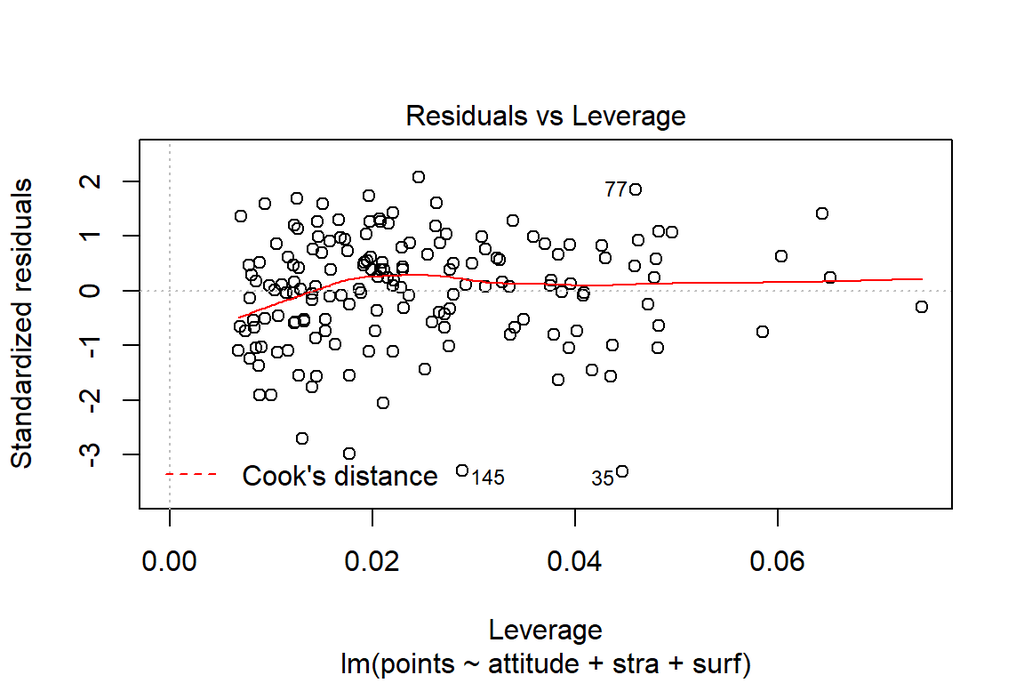

```r
model <- lm(points ~ attitude + stra + surf, data = lrn14)

plot(model, which = c(1,2,5))
```

Residuals looks to have mean zero, points are mostly normally distributed and there are no points with significally great leverage.